# Brazil’s Students Enrollment

Bruno Oliveira de Albuquerque

2022-07-04

## School Enrollment

School enrollment is a good measure to analyze how students are engaged in educational programs and how they are thinking about their futures as specialized workers.

As children spend more time studying, they could improve their knowledge and be able to work on a higher-demand job in the future.

In this analysis, we try to expose the influence of some indicators on students enrollment, focused primarily on Brazil’s context. The indicators that we will cover are:

- GDP invested in education
- Children from 7 to 14 years old that are employed
- Income distribution between classes of the population

To get the data about students enrollment and the indicators, a dataset form World Bank Group was used and more details about it could be obtained from its [website](https://datacatalog.worldbank.org/search/dataset/0037712/World-Development-Indicators).

We did some cleaning on the dataset so it could be more useful for our analysis.

```r
# Data obtained from https://datacatalog.worldbank.org/search/dataset/0037712/World-Development-Indicators at 04/07/2022
df_countries <- read_dataset('WDICountry.csv')
df_cleaned <- read_dataset('WDIData.csv') %>%
  # Getting data until 2019 to ignore pandemic situation
  select(c(country_code, indicator_code, x2010:x2019)) %>%
  # Removing rows where all year values are null
  filter(rowSums(is.na(.)) < 10) %>%
  # Getting income groups of each country
  merge(read_dataset('WDICountry.csv'), by='country_code') %>%
  select(c(country_code, income_group, indicator_code, x2010:x2019)) %>%
  # Removing countries not associated with any Income Group
  filter(!is.na(income_group)) %>%
  # Creating a different group to Brazil, to make it comparable with other groups
  mutate(income_group=if_else(country_code == 'BRA', 'Brazil', income_group))
```

Below there is a preview of how the dataset is organized.

|  | country_code | income_group | indicator_code | x2010 | x2011 | x2012 | x2013 | x2014 | x2015 | x2016 | x2017 | x2018 | x2019 |
| --- | --- | --- | --- | --- | --- | --- | --- | --- | --- | --- | --- | --- | --- |
| 1 | ABW | High income | EG.ELC.ACCS.ZS | 9.335629e+01 | 1.000e+02 | 1.000e+02 | 1.000e+02 | 1.000000e+02 | 1.000e+02 | 1.000e+02 | 1.00e+02 | 1.000e+02 | 100 |
| 2 | ABW | High income | EG.ELC.ACCS.RU.ZS | 1.000000e+02 | 1.000e+02 | 1.000e+02 | 1.000e+02 | 1.000000e+02 | 1.000e+02 | 1.000e+02 | 1.00e+02 | 1.000e+02 | 100 |
| 3 | ABW | High income | EG.ELC.ACCS.UR.ZS | 1.000000e+02 | 1.000e+02 | 1.000e+02 | 1.000e+02 | 1.000000e+02 | 1.000e+02 | 1.000e+02 | 1.00e+02 | 1.000e+02 | 100 |
| 4 | ABW | High income | SE.PRM.TENR | 9.891975e+01 | NA | NA | NA | 9.929199e+01 | NA | NA | NA | NA | NA |
| 5 | ABW | High income | NY.ADJ.NNTY.KD | NA | NA | NA | NA | NA | 2.522e+09 | NA | NA | NA | NA |
| 6 | ABW | High income | NY.ADJ.NNTY.CD | 2.007000e+09 | 2.035e+09 | 2.161e+09 | 2.281e+09 | 2.400000e+09 | 2.522e+09 | 2.529e+09 | 2.59e+09 | 2.648e+09 | NA |

### How is school enrollment improving over the last years?

To get a perspective of school enrollment, we checked indicators related to enrollments on main levels of education: primary, secondary and tertiary. The enrollments were grouped by the Income Group of the countries as defined on *WDICountry.csv* file. Only Brazil was taken off of its group (Upper middle income) to make it easier to compare with other groups.

The choice of indicators was made by using a spreadsheet with the *WDISeries.csv* file.

```r
## Primary and secondary indicators were net indicators so they could reflect better the students that needed to be at each level
# SE.PRM.NENR: School enrollment, primary (% net)
# SE.SEC.NENR: School enrollment, secondary (% net)
# SE.TER.ENRR: School enrollment, tertiary (% gross)
enrollment_indicators <- c('SE.PRM.NENR', 'SE.SEC.NENR', 'SE.TER.ENRR')
```

After determining the indicators, we tried to group the data in a way that we could show the differences between groups.

```r
df_enrollment <- df_cleaned %>%
  filter(indicator_code %in% enrollment_indicators) %>%
  # Getting only the last 5 year to get results based on previous years investments
  select(c(country_code, income_group, indicator_code, x2015:x2019)) %>%
  # pivoting table to make it easier to plot
  pivot_longer(x2015:x2019, names_to='year', values_to='enrollment') %>%
  # cleaning year values to make it easier to use as label
  mutate(year=gsub('x', '', .$year))
```

We also checked the presence of missing values on the metric variable of the dataset.

```
## Percentage of missing values on enrollment column: 40%
```

And as you can see, about 40% of our enrollment variable is filled with missing values.As this type of value does not change much between years, I used a strategy to fill the missing values based on previous years, and if there isn’t a previous year fill them with future data.

```r
df_enrollment <- df_enrollment %>%
  group_by(country_code, indicator_code) %>%
  # Using the filling strategy to get values from previous years, if it doesn't exist, get from future year
  fill(enrollment, .direction='downup') %>%
  # Filtering to get only the countries with at least 1 not missing value for each indicator
  filter(!is.na(enrollment))
```

To check how each group is improving on their enrollment level, we plotted a line chart showing the differences between them.

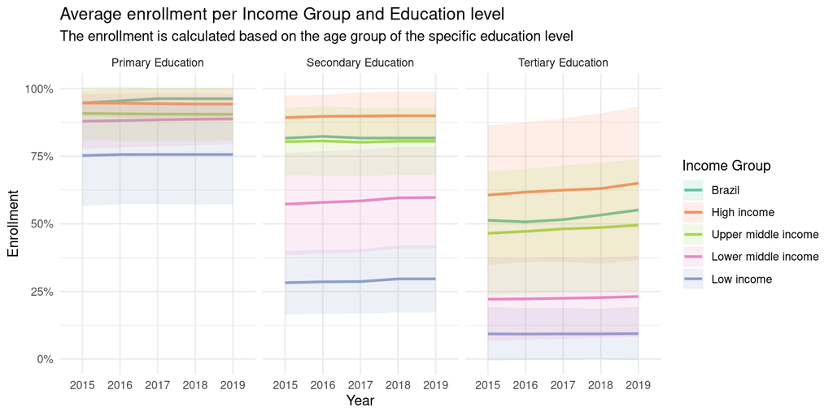

As we can see, there is a small difference in the Primary education level and it increases at the other levels. It could represent a less given importance to the other levels or some economic/social factor influences these variations. Another interesting observation is that there is a huge standard deviation (represented by the color shadows) inside each Income Group.

The problem with this is that children will become less capable of performing on more specialized jobs, making it difficult to improve the overall education quality of the countries.

In this analysis, we will give special attention to secondary education as it can serve as a baseline to help children acquire great improvements on their education.

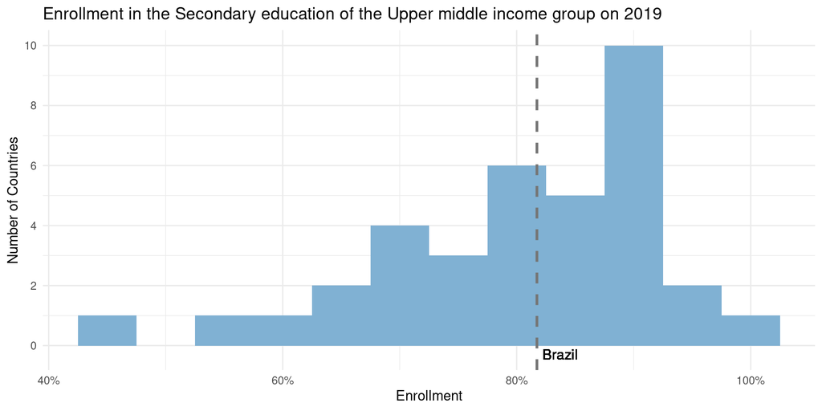

According to the values about secondary school enrollment using Upper middle income group data we could see that Brazil’s enrollment level is still below a large group of countries in the same group. So with this in mind, we check that there is a lot of room for improvement.

### What influence does money spent on education have?

To get started on which aspects could be improved to get a better school enrollment level, we analyzed data about GDP spent on education.

To clarify the concept, GDP (according to (OECD)[https://data.oecd.org/gdp/gross-domestic-product-gdp.htm]) “is the standard measure of the value added created through the production of goods and services in a country during a certain period”. So we thought that it could be a good starting point for our analysis.

The first step, as always was to group and clean the data about this indicator, that represents the percentage of the country’s GDP spent on education.

```r
# Checking the investment in education based on GDP
df_gdp_spent_percent <- df_cleaned %>%
  filter(indicator_code  == 'SE.XPD.TOTL.GD.ZS') %>%
  # Pivoting table to make it easier to plot
  pivot_longer(x2010:x2019, names_to='year', values_to='gdp_percent') %>%
  # Cleaning year values to make it easier to use as label
  mutate(year=gsub('x', '', .$year))
```

We checked the number of missing values to all indicators as it is a constant difficulty using this dataset, and in this case, we used the same strategy as the previous indicator, to fill the missing data using previous year data and if it doesn’t exist, getting data from future years.

```
## Percentage of missing values on gdp_percent column: 21%
```

```r
df_gdp_spent_percent <- df_gdp_spent_percent %>%
  group_by(country_code, indicator_code) %>%
  fill(gdp_percent, .direction='downup') %>%
  # filtering to get only the countries with at least 1 not missing value for each indicator
  filter(!is.na(gdp_percent))
```

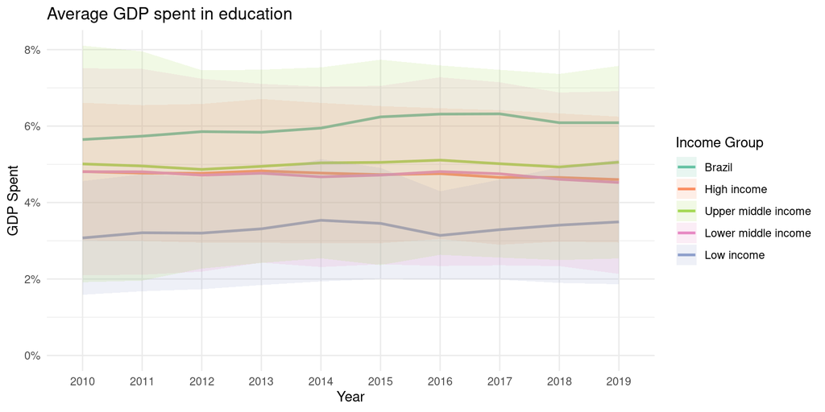

The chart above shows that there is little variation in the percentage of GDP spent on education among all countries during the last 10 years. So, we conclude that the GDP spent on education is not relevant to our analysis.

But wait! This is only part of the analysis on GDP because it covers only the variation in percentage and countries could have a huge difference in absolute values of GDP and GDP per capita. So we tried to extract this type of information and combine it with the data about expenditures on in education.

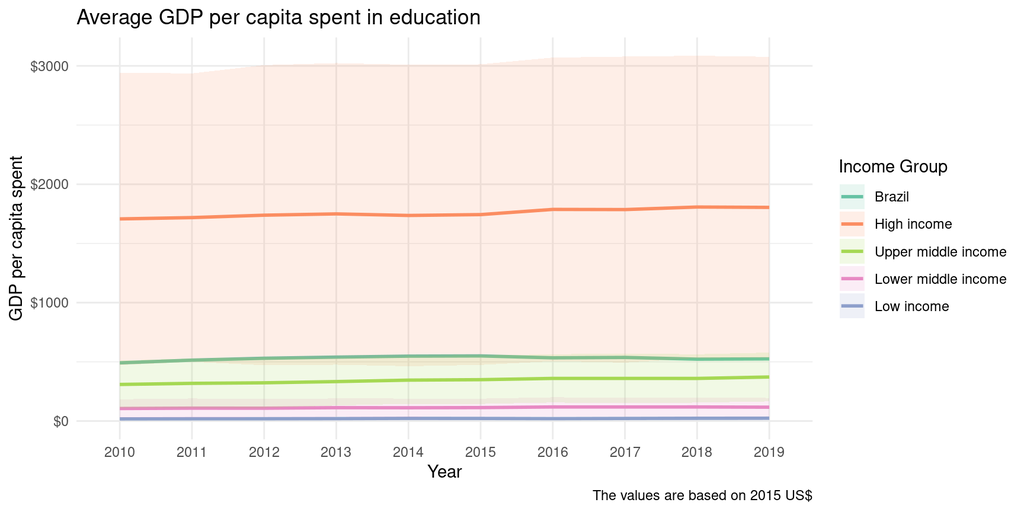

```r
# Getting GDP per capita changes over time
df_gdp <- df_cleaned %>%
  filter(indicator_code  == 'NY.GDP.PCAP.KD') %>%
  # Pivoting table to make it easier to plot
  pivot_longer(x2010:x2019, names_to='year', values_to='gdp_per_capita') %>%
  # Cleaning year values to make it easier to use as label
  mutate(year=gsub('x', '', .$year)) %>%
  group_by(country_code, indicator_code) %>%
  # Using the strategy to fill missing values to get similar number of coutries' values
  fill(gdp_per_capita, .direction='downup') %>%
  # Filtering to get only the countries with at least 1 not missing value for each indicator
  filter(!is.na(gdp_per_capita))

df_gdp_spent_per_capita <- df_gdp_spent_percent %>%
  # Joining with gdp data to be able to get the gpd expenditure per capita
  merge(df_gdp, by=c('country_code', 'year')) %>%
  rename(income_group=income_group.x) %>%
  select(c(country_code, year, income_group, gdp_percent, gdp_per_capita)) %>%
  # Getting the gdp spent per capita
  mutate(
    gdp_spent_per_capita=(gdp_percent/100) * gdp_per_capita,
    year=gsub('x', '', year))
```

Now we can see that the difference in absolute values of GDP per capita is very big between the High income group and other groups, with low variations during the last years.

[figure not shown]

### Do children with jobs have more or fewer oportunities?

After that, the impacts of children’s employment were studied to verify if there is some correlation with children’s enrollment in schools or not.

We expected there it would have, as children spending more time working will have less time available to evolve their education.

```r
# Getting data on children in employment 7 - 14 year
df_children_employment <- df_cleaned %>% filter(indicator_code  == 'SL.TLF.0714.ZS')
```

On this indicator, we changed the strategy of getting values from different years to show the variations. This happened because the number of missing values on it is so huge that was preferable to get only the last year with valid information.

To not get outdated information, we chose to pick the last available data from the last 5 years.

```
## Percentage of missing values on years columns: 84%
```

```r
df_children_employment <- df_children_employment %>%
  # Getting only the last year from the last five because there is a lot of missing values
  mutate(children_employment=do.call(coalesce, rev(across(x2015:x2019)))) %>%
  select(c(country_code, income_group, children_employment)) %>%
  filter(!is.na(children_employment))
```

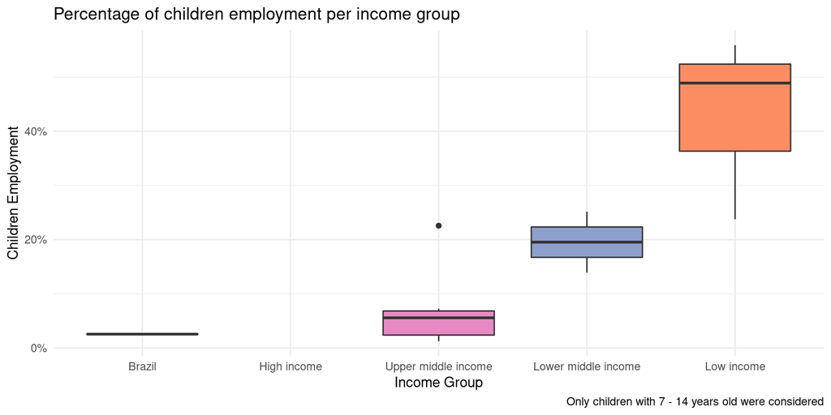

As we expected, countries with lower incomes have more children employed than those with higher incomes, showing a good correlation with the data about students enrollment.

On this chart we could not find significant data about High income countries, because of this, the part corresponding to it stayed blank. Analyzing Brazil’s position, we could check that it is in a good spot on this indicator.

### Is income distribution really a problem?

In the last step, we analyzed data about income share between population groups.

The population was divided into 5 categories representing the richest to the poorest people.

```r
# getting data about poverty !caution
# distribution of income share per group
# SI.DST.05TH.20: Income share held by highest 20%
# SI.DST.04TH.20: Income share held by fourth 20%
# SI.DST.03RD.20: Income share held by third 20%
# SI.DST.02ND.20: Income share held by second 20%
# SI.DST.FRST.20: Income share held by lowest 20%
poverty_indicators <- c('SI.DST.FRST.20', 'SI.DST.02ND.20' , 'SI.DST.03RD.20', 'SI.DST.04TH.20', 'SI.DST.05TH.20')
```

```r
df_poverty <- df_cleaned %>%
  filter(indicator_code %in% poverty_indicators) %>%
  # Pivoting table to make it easier to plot
  pivot_longer(x2010:x2019, names_to='year', values_to='income_share') %>%
  # Cleaning year values to make it easier to use as label
  mutate(year=gsub('x', '', year))
```

```
## Percentage of missing values on income_share column: 48%
```

```r
df_poverty <- df_poverty %>%
  group_by(country_code, indicator_code) %>%
  # Filling missing values so that each year could have the same number of countries
  fill(income_share, .direction='downup') %>%
  filter(!is.na(income_share))

df_poverty_grouped <- df_poverty %>%
  group_by(income_group, indicator_code, year) %>%
  summarise(mean=mean(income_share), sd=sd(income_share), .groups='drop_last') %>%
  # Getting the difference of values between years per group
  mutate(years_difference=abs(mean - lag(mean)))
```

To build a more interesting visualization, we checked if there is big variations of information through the years.

With the histogram below we could see that the variations in the values are very low, where a big part of the values varied less than 0.5% between years.

Using this information, we filtered the data to get only the last year information.

```
## Maximum difference of values between years: 1.3%
```

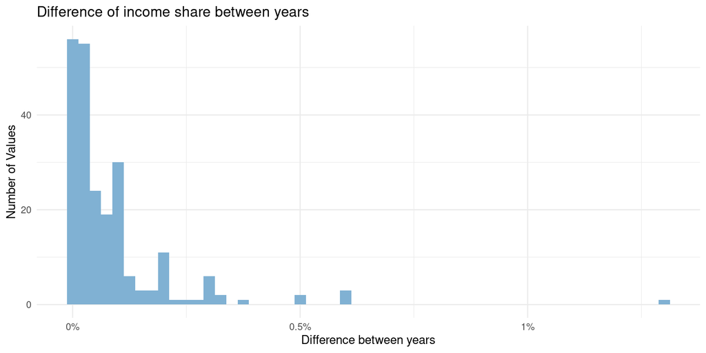

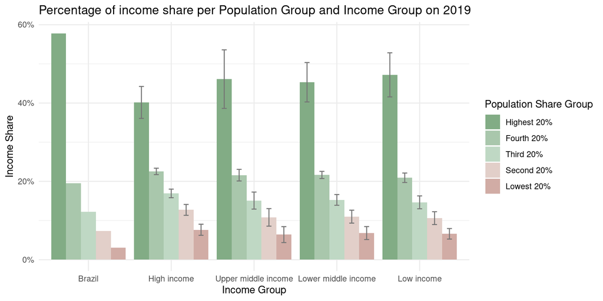

On the above chart we could get that in Brazil, the differences in income share between population groups are very big, bigger than in any other country analyzed. These differences could increase the difficulties that poorer people have to sustain their lives, making it harder for them to improve their education level.

We could also observe that High income countries have smaller variations through groups showing that a more balanced income distribution could leave people with better opportunities to continue their school enrollment.

## Conclusions

Using the World Bank data we could get some insights on which aspects Brazil could improve to offer better opportunities to its population, showing that to maintain children going to school investments in education are crucial, as well as sustaining low levels of children employment and reducing inequalities on income share through people.

## Future Analyses

As we discovered during the cleaning process of the data, there are a lot of missing values through it and with this we needed to make some assumptions on how the data would be on previous and future years. Regression algorithms could be used to obtain better predictions on the behavior of the data, but we tried to make the analysis simpler.

Another important aspect that could be noted is that World Bank could be considered a secondary source of the data on some indicators (and a good one) and some mistakes could have been done during the process of obtaining the data. So getting data from primary sources could direct us to bit different results.

## Final thoughts

In this analysis, we checked some indicators that we would believe that they could increase children’s enrollment in schools, but it is the most important part of education? Maybe children that study only at home could get better results than those that go to school. If this is true our whole analysis could be changed :)

Another thing that we have to pay attention to when working with data is that correlation is not the same as causation, so we need to be very careful with this assumptions.

I leave you guys with a last question, if you would like to change the education system in the whole world, what most unexpected thing would you change?

I end here with a last quote: “*Think differently, make lives better.*”